# FIN 6930 AI & ML Applications for Finance & FinTech

Assignment 1

Team member:

Weicheng Cao

Yang Dai

## Q1 Article Review

### How do AI tools such as machine/deep learning, natural language processing relate to financial services?

In financial services, AI tools can be used for financial decision-making and user interface. Financial institutions could use AI methods to improve their efficiency and cost management, and the user could enjoy efficient services and low service fees.

On the one hand, financial institutions and vendors would use AI and machine learning methods to manage the risks, predict a potential high-yield investment and optimize capital and portfolios. Besides, AI and machine learning could also complete the risk measuring that is inefficient for a human. For instance, Machine learning can incessantly capture the most sensitive news and investor sentiment indicators that might have an influence on the financial market.

On the other hand, users can also achieve the benefit from AI methods in finance. Machine & deep learning improved the processing accuracy of natural language for Chatbots. The users can enjoy an efficient financial service with low service fees.

In summary, AI methods are beneficial for financial service suppliers and users. It not only improves risk management and the prediction of valuable investments for financial institutions but also allows users can enjoy efficient services with low fees.

### How can AI be used to enhance compliance systems, customer interface, risk management, underwriting and investment strategies?

In the financial market, AI tools be used to enhance compliance systems, customer interface, risk management, underwriting, and investment strategies.

#### Enhance compliance systems

With the help of intelligent character recognition, RPA automates tedious and time-consuming tasks that previously consumed numerous work hours and increased expenses. By utilizing AI-powered software, data can be verified, reports can be generated based on specified parameters, and documents can be reviewed and information extracted from forms such as applications and agreements.

Implementing RPA for repetitive tasks with high frequency eradicates the potential for human errors and enables financial institutions to redirect their workforce towards tasks that demand human involvement.

#### Customer interface

Customer-centric applications of AI in the financial industry include credit scoring, insurance, and customer-facing chatbots. Advanced algorithms analyze extensive customer data to evaluate creditworthiness and determine loan pricing. Additionally, customer interactions are increasingly facilitated through AI interfaces, such as chatbots or virtual assistant programs, which engage with users in natural language.

#### Risk Management

AI has a profound impact on risk management in financial services. Its immense processing power enables quick handling of vast amounts of data, while cognitive computing effectively manages structured and unstructured data. Algorithms analyze historical risk cases and detect early signs of potential issues. AI’s real-time analysis and accurate predictions, based on multiple variables, are crucial for business planning.

#### Investment Strategy

AI Trading Systems efficiently monitor both structured (databases, spreadsheets, etc.) and unstructured (social media, news, etc.) data, processing it much faster than humans. Besides, with algorithms capable of testing trading systems using historical data, stock performance predictions become more accurate, elevating the validation process to a new level before implementation.

Furthermore, AI plays a crucial role in recommending strong portfolios tailored to specific investors’ short- and long-term goals. For instance, Bloomberg’s AI-powered application, called “Alpaca Forecast AI Prediction Matrix”, combines real-time market data from Bloomberg with advanced learning capabilities to identify price movement patterns, enabling high-accuracy market predictions.

# K-Means Machine Learning

## 4 Features with K = 3

When we applied the cluster for 4 features with K = 3, some countries' risk clusters were also changed. The number of high-risk countries (0 label) was increased. The changes status for the parts of 7 countries we selected are below:

a. South Africa changed from 0 to 2

b. China changed from 1 to 0

c. India changed from 1 to 0

d. Jamaica changed from 2 to 0

Within 4 features instead of 3 features, some countries’ risk scores were increased.

## Q2 All Features with K = 4

When we applied the cluster for 4 features with K =4, some countries' risk clusters were changed (0 means highest risk). Besides, the high-risk countries within 4 features were labeled more than within 3 features. The changes in risk status for the parts of 7 countries we selected are below:

a. South Korea changed from 2 to 0

b. Russia changed from 0 to 3

c. Ukraine changed from 0 to 3

d. Mexico changed from 0 to 3

e. Turkey changed from 0 to 3

f. Zimbabwe changed from 0 to 3

Within 4 features instead of 3 features, some countries’ risk scores were reversal. It is known that legal and corruption are not independent variables due to their high correlation coefficient, and this would lead to some results reversal.

The reason might be that the overmuch clusters result in overfitting for the machine learning. This means that overmuch clustering can cause the model to be oversensitive to training data and cannot generalize to new unseen data. Therefore, the model would pick up noise or subtle differences in the training data rather than actual data patterns or structures.

## Conclusion

In conclusion, the increase in the number of dependent features might cause overfitting and a low explanation for the model. The reason is that the overmuch features result in the model being oversensitive, and the model would pick up noise or subtle differences in the training data rather than actual data patterns or structures.

## K-Means Code

```python
# loading packages

import os

import pandas as pd
import numpy as np

# plotting packages
%matplotlib inline
from mpl_toolkits.mplot3d import Axes3D
import matplotlib.pyplot as plt
import matplotlib.cm as cm
import matplotlib.colors as clrs

# Kmeans algorithm from scikit-learn
from sklearn.cluster import KMeans
from sklearn.metrics import silhouette_samples, silhouette_score

# import packages
import warnings
warnings.filterwarnings('ignore')

import pandas as pd
import numpy as np

import seaborn as sns
import matplotlib.pyplot as plt

from sklearn.linear_model import LogisticRegression

from sklearn.metrics import accuracy_score, recall_score, precision_score, f1_score
from sklearn.metrics import confusion_matrix, classification_report, roc_curve, roc_auc_score
from sklearn.metrics import precision_recall_curve, auc, average_precision_score

from sklearn.tree import DecisionTreeClassifier, plot_tree, export_graphviz, export_text
from sklearn.preprocessing import StandardScaler
from IPython.display import Image
from sklearn.metrics import accuracy_score, recall_score, precision_score
from sklearn.metrics import confusion_matrix, classification_report, roc_auc_score
from sklearn.metrics import roc_curve, auc, average_precision_score
```

### Load raw data

```python
# load raw data
DATA_FOLDER = '/Users/caoweicheng/Desktop/UF书籍/AI and Machine Learning/ML/Unsupervised Learning - K mean'
raw = pd.read_csv(os.path.join(DATA_FOLDER, 'country risk 2019 data.csv'))

# check the raw data
print("Size of the dataset (row, col): ", raw.shape)
print("\nFirst 5 rows\n", raw.head(n=5))
```

```
Size of the dataset (row, col):  (121, 6)

First 5 rows
      Country Abbrev  Corruption  Peace  Legal  GDP Growth
0    Albania     AL          35  1.821  4.546       2.983
1    Algeria     DZ          35  2.219  4.435       2.553
2  Argentina     AR          45  1.989  5.087      -3.061
3    Armenia     AM          42  2.294  4.812       6.000
4  Australia     AU          77  1.419  8.363       1.713
```

### Simple exploratory analysis

#### Print summary statistics

```python
# print summary statistics
print("\nSummary statistics\n", raw.describe())
print("\nCorrelation matrix\n", raw.corr())
```

```
Summary statistics
        Corruption       Peace       Legal  GDP Growth
count  121.000000  121.000000  121.000000  121.000000
mean    46.842975    2.001017    5.752529    2.657529
std     18.702499    0.461485    1.373932    2.563741
min     15.000000    1.072000    2.671000   -9.459000
25%     33.000000    1.699000    4.785000    1.249000
50%     41.000000    1.939000    5.455000    2.600000
75%     60.000000    2.294000    6.488000    4.000000
max     87.000000    3.369000    8.712000    7.800000

Correlation matrix
             Corruption     Peace     Legal  GDP Growth
Corruption    1.000000 -0.705002  0.938512   -0.123545
Peace        -0.705002  1.000000 -0.662233   -0.004428
Legal         0.938512 -0.662233  1.000000   -0.150369
GDP Growth   -0.123545 -0.004428 -0.150369    1.000000
```

#### Plot histogram

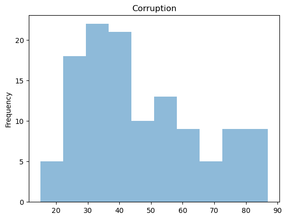

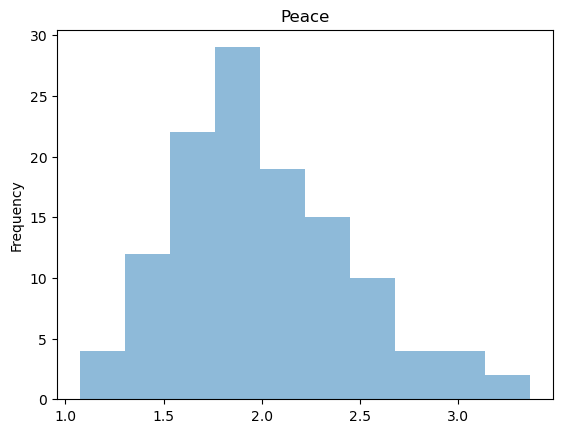

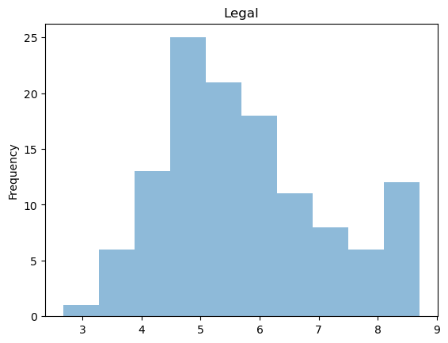

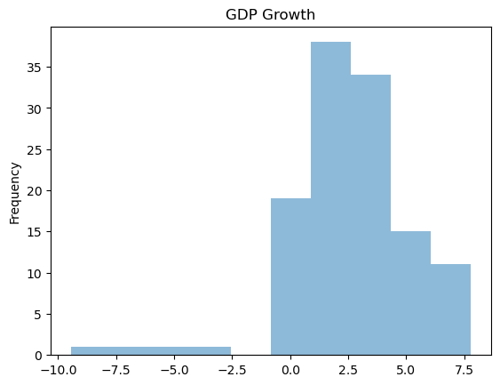

```python
# plot histograms
plt.figure(1)
raw['Corruption'].plot(kind = 'hist', title = 'Corruption', alpha = 0.5)

plt.figure(2)
raw['Peace'].plot(kind = 'hist', title = 'Peace', alpha = 0.5)

plt.figure(3)
raw['Legal'].plot(kind = 'hist', title = 'Legal', alpha = 0.5)

plt.figure(4)
raw['GDP Growth'].plot(kind = 'hist', title = 'GDP Growth', alpha = 0.5)

plt.show()
```

### K means cluster

#### Pick features & normalization

```python
X = raw[['Peace','Corruption', 'Legal', 'GDP Growth']] # Pick all 4 features
scaler = StandardScaler() # the function for standardizing data
print(X.head(5))
```

```
   Peace  Corruption  Legal  GDP Growth
0  1.821          35  4.546       2.983
1  2.219          35  4.435       2.553
2  1.989          45  5.087      -3.061
3  2.294          42  4.812       6.000
4  1.419          77  8.363       1.713
```

#### Perform elbow method

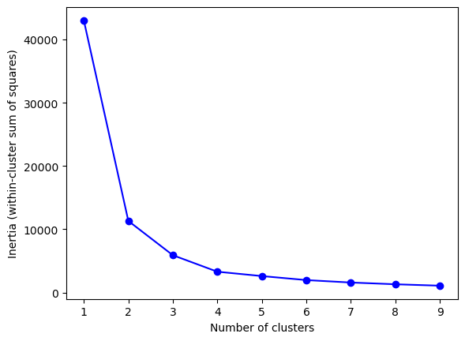

```python
# K = 3
Ks = range(1, 10)
inertia = [KMeans(i).fit(X).inertia_ for i in Ks]

fig = plt.figure()
plt.plot(Ks, inertia, '-bo')
plt.xlabel('Number of clusters')
plt.ylabel('Inertia (within-cluster sum of squares)')
plt.show()
```

#### K means with k=3

```python
k = 3
kmeans = KMeans(n_clusters=k, random_state=1)
kmeans.fit(X)

# print inertia & cluster center
print("inertia for k=4 is", kmeans.inertia_)
print("cluster centers: ", kmeans.cluster_centers_)

# take a quick look at the result
y = kmeans.labels_
print("cluster labels: ", y)
```

```
inertia for k=4 is 5900.48181670854
cluster centers:  [[ 2.25551515 32.66666667  4.80466667  2.98128788]
 [ 1.53508696 77.82608696  7.92869565  1.58630435]
 [ 1.811      53.8125      6.143375    2.75971875]]
cluster labels:  [0 0 2 0 1 1 0 0 0 1 0 0 0 2 0 0 0 0 1 0 1 0 0 2 2 2 2 0 1 2 0 0 0 1 0 1 1
 0 2 1 0 2 0 0 2 1 0 0 0 1 2 2 0 1 2 0 0 2 0 2 0 0 2 0 0 2 0 0 2 0 0 2 0 0
 0 1 1 0 0 1 2 0 0 0 0 0 2 2 2 2 0 2 2 2 0 0 1 2 2 2 2 0 1 1 2 0 0 0 0 0 0
 0 0 1 1 1 1 0 0 0 0]
```

#### Visualize the result (3D plot)

[figure not shown]

```python
# set up the color
norm = clrs.Normalize(vmin=0.,vmax=y.max() + 0.8)
cmap = cm.viridis

fig = plt.figure()
ax = fig.add_subplot(111, projection='3d')

ax.scatter(X.iloc[:,0], X.iloc[:,1], X.iloc[:,2], c=cmap(norm(y)), marker='o')

centers = kmeans.cluster_centers_
ax.scatter(centers[:, 0], centers[:, 1], c='black', s=100, alpha=0.5)

ax.set_xlabel('Peace')
ax.set_ylabel('Legal & Corruption')
ax.set_zlabel('GDP Growth')

plt.show()
```

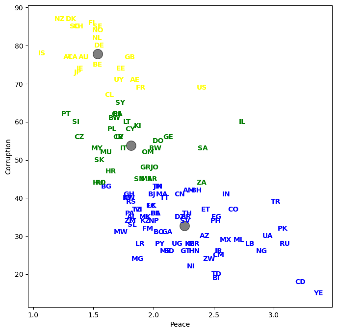

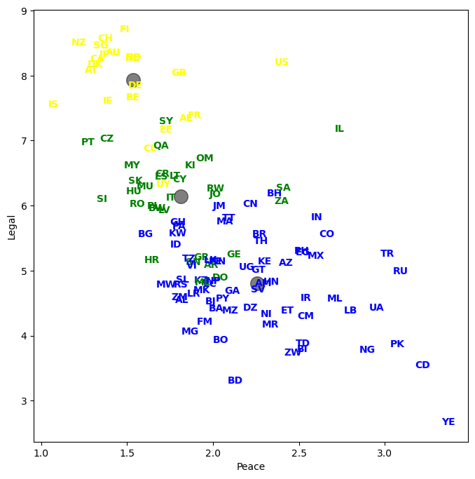

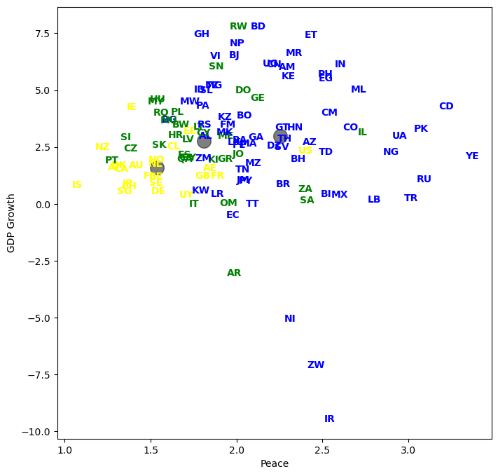

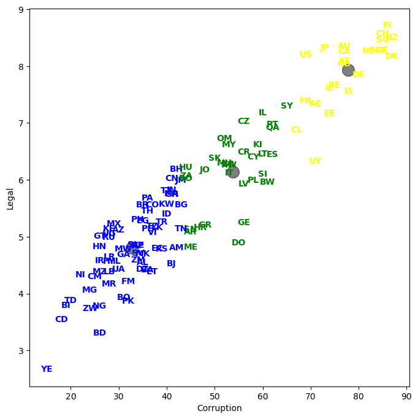

```python
%matplotlib inline
import matplotlib.pyplot as plt

figs = [(0, 1), (0, 2),(0, 3),(1, 2),(1, 3),(2, 3)]
labels = ['Peace','Corruption', 'Legal', 'GDP Growth']
colors = ['blue','yellow','green', 'red']

for i in range(4):
    fig = plt.figure(i, figsize=(8, 8))
    x_1 = figs[i][0]
    x_2 = figs[i][1]
    plt.scatter(X.iloc[:, x_1], X.iloc[:, x_2], c=y, s=0, alpha=0)
    plt.scatter(centers[:, x_1], centers[:, x_2], c='black', s=200, alpha=0.5)
    for j in range(X.shape[0]):
        plt.text(X.iloc[j, x_1], X.iloc[j, x_2], raw['Abbrev'].iloc[j],
                 color=colors[y[j]], weight='semibold', horizontalalignment = 'center', verticalalignment = 'center')
    plt.xlabel(labels[x_1])
    plt.ylabel(labels[x_2])

plt.show()
```

#### List the result

```python
result = pd.DataFrame({'Country':raw['Country'], 'Abbrev':raw['Abbrev'], 'Label':y})
with pd.option_context('display.max_rows', None, 'display.max_columns', 3):
    print(result.sort_values('Label'))
```

```
                          Country Abbrev  Label
0                         Albania     AL      0
73                     Mozambique     MZ      0
72                        Morocco     MA      0
70                        Moldova     FM      0
69                         Mexico     MX      0
67                     Mauritania     MR      0
66                           Mali     ML      0
64                         Malawi     MW      0
63                     Madagascar     MG      0
61                        Liberia     LR      0
119                        Zambia     ZM      0
58                         Kuwait     KW      0
56                          Kenya     KE      0
55                     Kazakhstan     KZ      0
```

[output cut: 107 more lines]

### Silhouette Analysis

```python
# Silhouette Analysis
range_n_clusters=[2,3,4,5,6,7,8,9,10]
for n_clusters in range_n_clusters:
    clusterer=KMeans(n_clusters=n_clusters, random_state=1)
    cluster_labels=clusterer.fit_predict(X)
    silhouette_avg=silhouette_score(X,cluster_labels)
    print("For n_clusters=", n_clusters,
          "The average silhouette_score is :", silhouette_avg)
```

```
For n_clusters= 2 The average silhouette_score is : 0.6305624056284236
For n_clusters= 3 The average silhouette_score is : 0.5555486671024561
For n_clusters= 4 The average silhouette_score is : 0.5246822625446153
For n_clusters= 5 The average silhouette_score is : 0.46886377251337624
For n_clusters= 6 The average silhouette_score is : 0.4619781964366212
For n_clusters= 7 The average silhouette_score is : 0.4688116874987868
For n_clusters= 8 The average silhouette_score is : 0.4447640755226805
For n_clusters= 9 The average silhouette_score is : 0.4653948768997516
For n_clusters= 10 The average silhouette_score is : 0.4669452495888109
```

# HW1 Q3

Lending Club Case

```python
# import packages
import warnings
warnings.filterwarnings('ignore')

import os

import pandas as pd
import numpy as np

import seaborn as sns
import matplotlib.pyplot as plt

from sklearn.linear_model import LogisticRegression

from sklearn.metrics import accuracy_score, recall_score, precision_score, f1_score
from sklearn.metrics import confusion_matrix, classification_report, roc_curve, roc_auc_score
from sklearn.metrics import precision_recall_curve, auc, average_precision_score

from sklearn.tree import DecisionTreeClassifier, plot_tree, export_graphviz, export_text
from sklearn.preprocessing import StandardScaler
from IPython.display import Image
from sklearn.metrics import accuracy_score, recall_score, precision_score
from sklearn.metrics import confusion_matrix, classification_report, roc_auc_score
from sklearn.metrics import roc_curve, auc, average_precision_score
```

## 3 Types of Data Set

```python
# train set, validation set, and test set
DATA_FOLDER = '/Users/caoweicheng/Desktop/UF书籍/AI and Machine Learning/ML/Supervised Learning（Regression）/Lending Club Case'
train = pd.read_excel(os.path.join(DATA_FOLDER, 'LendingClub_Decision_Trees_Training_Set.xlsx'))
validation = pd.read_excel(os.path.join(DATA_FOLDER, 'LendingClub_Decision_Trees_Validation_Set.xlsx'))
test = pd.read_excel(os.path.join(DATA_FOLDER, 'LendingClub_Decision_Trees_Test_Set.xlsx'))

# 1 = good, 0 = default

# give column names
cols = ['home_ownership', 'income', 'dti', 'fico', 'loan_status']

train.columns = validation.columns = test.columns = cols

print(train.head())
print("--------------------------------")
print(validation.head())
print("--------------------------------")
print(test.head())
```

```
   home_ownership    income    dti  fico  loan_status
0               1   44304.0  18.47   690            0
1               0   50000.0  29.62   735            1
2               0   64400.0  16.68   675            1
3               0   38500.0  33.73   660            0
4               1  118000.0  26.66   665            1
--------------------------------
   home_ownership    income    dti  fico  loan_status
0               0   25000.0  27.60   660            0
1               0   50000.0  21.51   715            1
2               1  100000.0   8.14   770            1
3               0   75000.0   1.76   685            0
4               1   78000.0  16.11   680            1
--------------------------------
   home_ownership    income    dti  fico  loan_status
0               1   52400.0  24.64   665            1
1               1  150000.0  17.04   785            1
2               1  100000.0  20.92   710            1
3               0   97000.0  13.11   705            1
4               1  100000.0  24.08   685            0
```

```python
# remove target column to create feature only dataset
x_train = train.drop('loan_status', 1)
x_val=validation.drop('loan_status', 1)
x_test = test.drop('loan_status', 1)

# store target column as y-variables
y_train = train['loan_status']
y_val=validation['loan_status']
y_test = test['loan_status']

#print first five instances for each data set

print(x_train.head())
print("----------------------------------------")
print(x_val.head())
print("----------------------------------------")
print(x_test.head())

print(x_train.shape, y_train.shape, x_val.shape,y_val.shape, x_test.shape, y_test.shape)
x_train.columns
```

```
   home_ownership    income    dti  fico
0               1   44304.0  18.47   690
1               0   50000.0  29.62   735
2               0   64400.0  16.68   675
3               0   38500.0  33.73   660
4               1  118000.0  26.66   665
----------------------------------------
   home_ownership    income    dti  fico
0               0   25000.0  27.60   660
1               0   50000.0  21.51   715
2               1  100000.0   8.14   770
3               0   75000.0   1.76   685
4               1   78000.0  16.11   680
----------------------------------------
   home_ownership    income    dti  fico
0               1   52400.0  24.64   665
1               1  150000.0  17.04   785
2               1  100000.0  20.92   710
3               0   97000.0  13.11   705
4               1  100000.0  24.08   685
(7000, 4) (7000,) (3000, 4) (3000,) (2290, 4) (2290,)
```

```
Index(['home_ownership', 'income', 'dti', 'fico'], dtype='object')
```

## Normalization Data

```python
# normalization Data

scaler = StandardScaler() # the function for standardizing data

# store the standardized data
x_scaled_train = scaler.fit_transform(x_train)
x_scaled_val = scaler.fit_transform(x_val)
x_scaled_test = scaler.fit_transform(x_test)

print(x_scaled_train[:, 0:4])
print('--------------------------------------------')
print(x_scaled_val[:, 0:4])
print('--------------------------------------------')
print(x_scaled_test[:, 0:4])
```

```
[[ 0.80970929 -0.55627204  0.05310543 -0.16371231]
 [-1.23501114 -0.45142494  1.30747958  1.26262923]
 [-1.23501114 -0.18636206 -0.14826944 -0.63915949]
 ...
 [ 0.80970929  0.1007894  -0.71076906 -0.16371231]
 [-1.23501114 -0.67376485  1.67085434  0.31173487]
 [ 0.80970929 -0.2673535  -0.27426935 -0.4806771 ]]
--------------------------------------------
[[-1.26388393 -1.03817605  1.16909791 -1.15519021]
 [-1.26388393 -0.51979438  0.43635803  0.62078356]
 [ 0.79121189  0.51696897 -1.17230079  2.39675732]
 ...
 [ 0.79121189 -0.27097118  1.26775911  0.29787924]
 [-1.26388393 -0.9921504  -0.74637317  0.62078356]
 [ 0.79121189  0.4340279   0.5783339  -0.18647725]]
--------------------------------------------
[[ 0.82993407 -0.43346185  0.83898133 -0.97846117]
 [ 0.82993407  1.25787031 -0.07812993  2.79186947]
 [ 0.82993407  0.39140916  0.3900795   0.43541282]
 ...
 [-1.20491499 -0.80430723  0.50109824  0.59250993]
 [ 0.82993407  0.01016625 -0.97834705 -0.35007273]
 [-1.20491499  0.07948315 -0.71648764 -0.19297562]]
```

## Collect All Threshold X Value

```python
# Collect all threshold X value in a single list
# Starting from X = $34,000 all the way to $120,000
# in increments of $8,600

num_X = 11 # the times of increments
X = 34000
X_list = []
for i in range(num_X):
    X_list.append(X)
    X+=8600
X_list
```

```
[34000,
 42600,
 51200,
 59800,
 68400,
 77000,
 85600,
 94200,
 102800,
 111400,
 120000]
```

## Define Entropy Function

```python
def entropy(p1,p2,p3):
    a = - p2*np.log2(p2) - (1-p2)*np.log2(1-p2)
    b = - p3*np.log2(p3) - (1-p3)*np.log2(1-p3)
    e = p1*a+(1-p1)*b
    return e
```

```python
# Check that the code matches the cases
# where X = 48,079
df = pd.DataFrame()
X = 48079
df['income'] = np.where(train['income']>=X, 1, 0)
df['loan_status'] = train['loan_status']
df
```

|  | income | loan_status |
| --- | --- | --- |
| 0 | 0 | 0 |
| 1 | 1 | 1 |
| 2 | 1 | 1 |
| 3 | 0 | 0 |
| 4 | 1 | 1 |
| ... | ... | ... |
| 6995 | 1 | 1 |
| 6996 | 0 | 1 |
| 6997 | 1 | 1 |
| 6998 | 0 | 0 |
| 6999 | 1 | 1 |

7000 rows × 2 columns

## Proportion of variables in training set

```python
# Proportion of income in training set that is greater than X
P1 = df["income"].value_counts(normalize=True)[1]

# proporation of applicants in training set with income greater than X that do not default
income_1 = df[df["income"] == 1]
P2 = income_1["loan_status"].value_counts(normalize=True)[1]

# proporation of applicants in training set with income less than X that do not default
income_0 = df[df["income"] == 0]
P3 = income_0["loan_status"].value_counts(normalize=True)[1]

P1, P2, P3
```

```
(0.7084285714285714, 0.8114539221617262, 0.7437530622243999)
```

## List All Threshold

```python
# Loop through all the threshold values in the X set
# The goal here is to determine the threshold X that will make
# Income the most comptetive to be considered for a root node
# Therefore, at a minimum, it has to genrate the lowest entropy value
# Then, it will be tested against the other features based on expected gain information as described on slide 14

Income_as_Root=[]
for x in X_list:
    df['income'] = np.where(train['income']>=x, 1, 0)
    df["loan_status"] = train["loan_status"]
    p1 = df['income'].value_counts(normalize = True)[1]
    income_1 = df[df['income']==1]
    p2 = income_1['loan_status'].value_counts(normalize = True)[1]
    income_0=df[df['income'] == 0]
    p3 = income_0['loan_status'].value_counts(normalize = True)[1]
    e = entropy(p1,p2,p3)
    Income_as_Root.append([x,p1,p2,p3,e])

Income_as_Root_df = pd.DataFrame(Income_as_Root, columns=["Threshold", "P1","P2","P3","Entropy"])
Income_as_Root_df
```

|  | Threshold | P1 | P2 | P3 | Entropy |
| --- | --- | --- | --- | --- | --- |
| 0 | 34000 | 0.901571 | 0.800982 | 0.706821 | 0.735002 |
| 1 | 42600 | 0.784000 | 0.803754 | 0.748016 | 0.735968 |
| 2 | 51200 | 0.662143 | 0.811650 | 0.752643 | 0.734852 |
| 3 | 59800 | 0.567000 | 0.815319 | 0.760805 | 0.735022 |
| 4 | 68400 | 0.441000 | 0.823129 | 0.766931 | 0.734752 |
| 5 | 77000 | 0.348000 | 0.829228 | 0.771691 | 0.734828 |
| 6 | 85600 | 0.270286 | 0.838795 | 0.774276 | 0.734454 |
| 7 | 94200 | 0.219857 | 0.840156 | 0.778063 | 0.735162 |
| 8 | 102800 | 0.164714 | 0.837814 | 0.782624 | 0.736268 |
| 9 | 111400 | 0.129429 | 0.836645 | 0.785034 | 0.736813 |
| 10 | 120000 | 0.112000 | 0.829082 | 0.787001 | 0.737390 |

## Smallest Entropy

```python
# Find the threshold X with smallest Entropy
Income_as_Root_df.loc[Income_as_Root_df["Entropy"]==min(Income_as_Root_df["Entropy"])]
```

|  | Threshold | P1 | P2 | P3 | Entropy |
| --- | --- | --- | --- | --- | --- |
| 6 | 85600 | 0.270286 | 0.838795 | 0.774276 | 0.734454 |

## Threshold 6 would be good choice for the root node

We should pick the smallest entropy to maximize the information gain. In other words, the smallest entropy would be a good choice. Therefore, the income of 85600, threshold 6, should be good for the root node due to its smallest entropy.

# HW1 Q4

```python
# Import ROC and AUC Function

from sklearn.metrics import roc_auc_score
from sklearn.metrics import roc_curve, auc, average_precision_score
```

## 3 Types of Data Set

```python
# remove target colum to create feature only dataset
# remove target column to create feature only dataset
x_train = train.drop('loan_status', 1)
x_val=validation.drop('loan_status', 1)
x_test = test.drop('loan_status', 1)

# store target column as y-variables
y_train = train['loan_status']
y_val=validation['loan_status']
y_test = test['loan_status']


print(x_train.shape, y_train.shape, x_val.shape,y_val.shape, x_test.shape, y_test.shape)
x_train.columns
```

```
(7000, 4) (7000,) (3000, 4) (3000,) (2290, 4) (2290,)
```

```
Index(['home_ownership', 'income', 'dti', 'fico'], dtype='object')
```

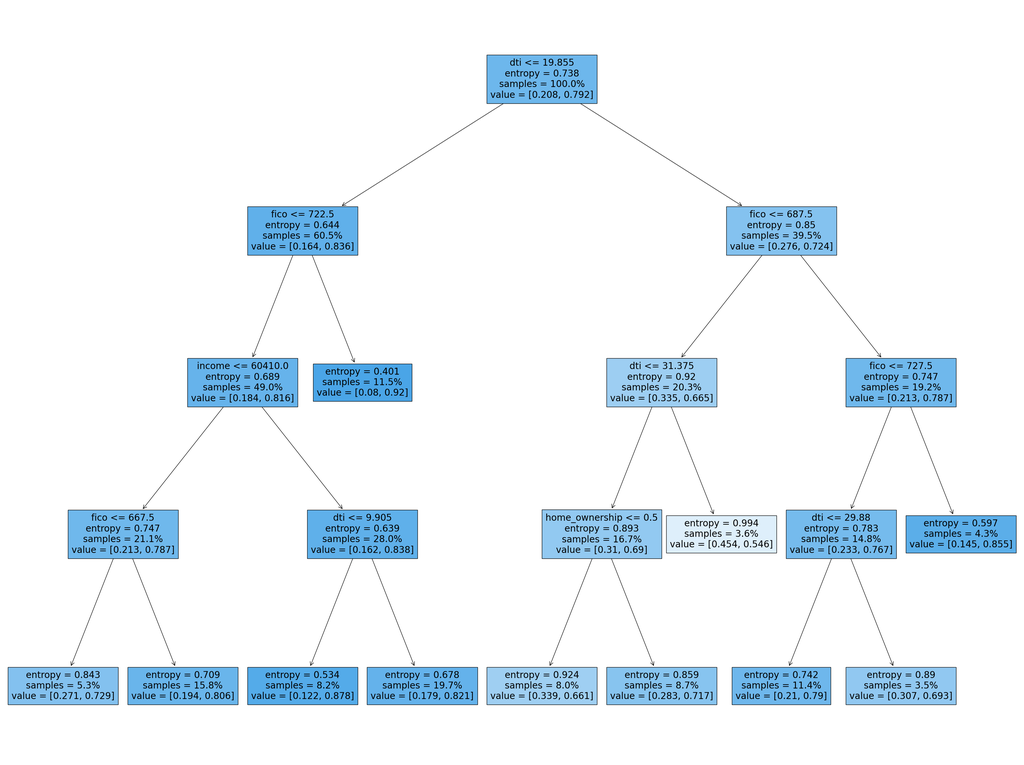

```python
# This section is to reproduce slide 18 of "Supervised Learning/Decision Trees"
# Decision Tree Framework
clf = DecisionTreeClassifier(criterion = 'entropy', max_depth=4, min_samples_split=1000, min_samples_leaf=200, random_state=0)

# Plot the Decision Tree figure
clf = clf.fit(x_train, y_train)
fig, ax = plt.subplots(figsize=(40, 30))
plot_tree(clf, filled = True, feature_names=x_train.columns, proportion=True)
plt.show()
```

## ROC Curve and AUC

```python
# Applicate the ROC and AUC

Q = clf.predict_proba(x_test)[:,1] # Compare the results for data set between train and test.

fpr, tpr, _ = roc_curve(y_test, Q) # False Positive Rate (fpr) and True Positive Rate (tpr)
roc_auc = auc(fpr, tpr) # Area Under the Curve (AUC)
```

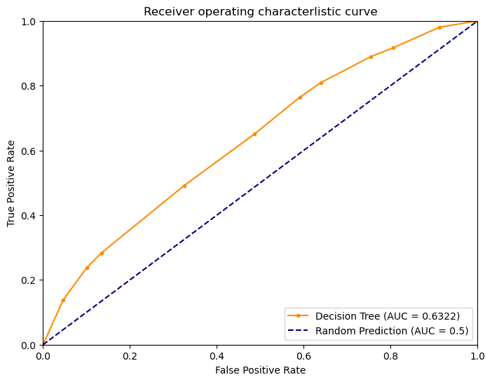

```python
# Format the plot size

plt.figure(figsize=(8, 6))
lw = 1.5

# Plot the ROC curve and show the AUC
plt.plot(fpr, tpr, color = 'darkorange', marker='.',
        lw = lw, label = 'Decision Tree (AUC = %0.4f)' % roc_auc)
plt.plot([0, 1], [0,1], color = 'navy', lw=lw, linestyle='--',
        label = 'Random Prediction (AUC = 0.5)')

# Format the figure
plt.xlim([0.0, 1.0])
plt.ylim([0.0, 1.0])
plt.xlabel('False Positive Rate')
plt.ylabel('True Positive Rate')
plt.title('Receiver operating characterlistic curve')
plt.legend(loc = "lower right")
plt.show() # Show anything
```